# Cunning Stunts Giro 2016 Recap

03 May 2017

### Introduction

Although I’m not likely to live up to Ralphy’s standard, I’m going to attempt daily scoring updates as we press on through the first of the Grand Tours this year. As a bit of a warm up, I thought it would be interesting to recap our 2016 Giro competition.

With a full complement of 7 teams in our 2016 Giro Velogames competition there was the opportunity for 7 unique teams and 63 riders in total. However the short list of favoured athletes in each category ultimately led us to select our squads from only 41 of the overall 198 riders starting the Giro in Apeldoorn on the 6th of May, 2016.

| Rider | Times Selected |
| --- | --- |
| Tom Dumoulin | 5 |
| Alejandro Valverde | 4 |
| Caleb Ewan | 4 |
| Johan Esteban Chaves | 3 |
| Rafał Majka | 3 |
| Vincenzo Nibali | 3 |
| Jack Bobridge | 2 |
| Marcel Kittel | 2 |
| Matthias Brändle | 2 |
| Rigoberto Uran | 2 |
| Ryder Hesjedal | 2 |
| Tim Wellens | 2 |

The most popular rider by far was Dutchman Tom Dumoulin with five of us selecting the man who defaulted to a pro cycling career after not securing a place in medical school.

### Top Ten Riders

But of course, picking riders on reputation and past performance was no guarantee of success in the first of the year’s Grand Tours. The top ten highest scoring riders for the Giro, in order were:

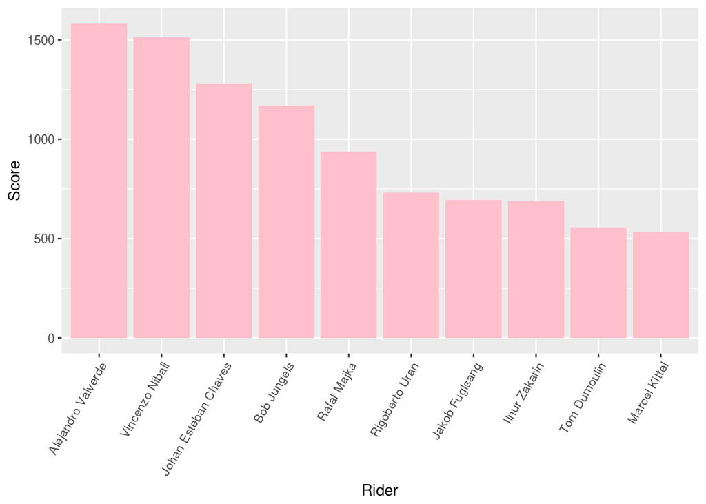

The top ten highest scoring riders for the Giro, based on Return on Investment were:

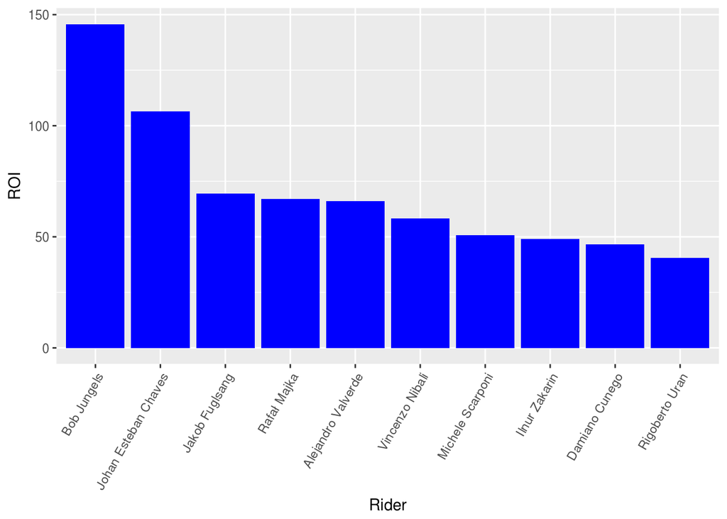

The ROI data is insightful in that it reveals which riders provided the best bang for buck. Although expensive picks such as Valverde and Nibali ultimately proved velocredits well spent, the three teams backing diminutive Columbian Esteban Chaves must have been cheering all the way to the Velocredit bank! Note - clearly the bargain pick at only 8 Velocredits was Bobby Jungels however the only team directeur savvy enough to select the lightweight Etixx Quickstep rider still finished with the wooden spoon….

### Overall Team Performance

At the end of a tightly fought three week battle the Fly Guys took top step on the podium by a very slim margin.

| Team | Directeur | Total |
| --- | --- | --- |
| Fly Guys | Stew Ralph | 4932 |
| The Bandits | Brendan Smith | 4906 |
| my team | edmundg | 4366 |
| Stinkys Strokers | Lee Taylor | 4301 |
| Aaron Turner | Btrain | 4241 |
| Brake Rub Regression | Simon Lyons | 4231 |
| Cooper`s Crankers | Ben Neal | 3658 |

### Individual Stage Performance

Early form from Ben’s Cooper’s Crankers and my Brake Rub Regression outfits wilted by the time we hit the mountains, with Valverde saving me from the spoon.

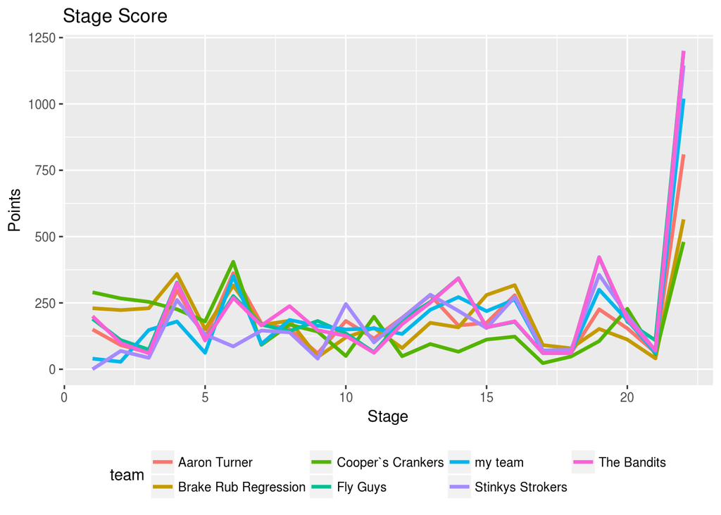

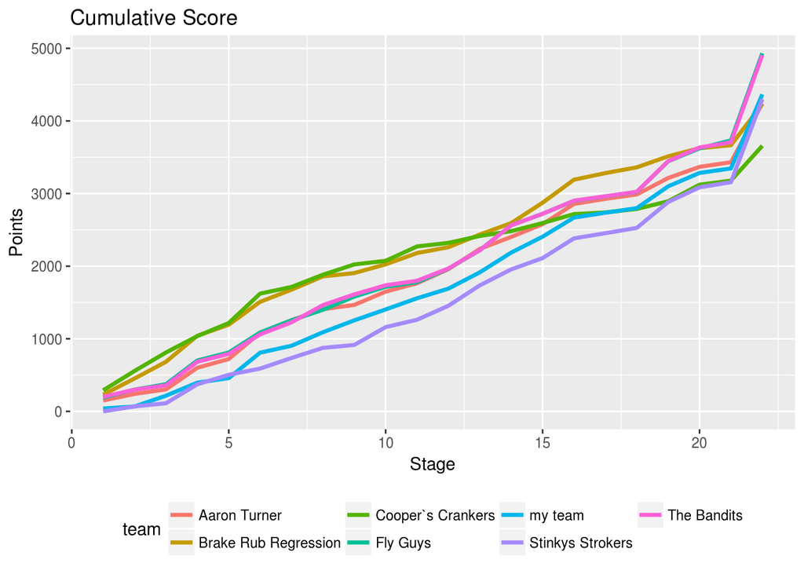

Whilst there was some diversity of top scoring riders for the teams on our Giro podium, it’s obvious that Chaves was a smart buy. Will the man filling the same role for Orica in 2017 prove to be equally good buying, also on only 12 velocredits?

Rider Scores - Top Teams

| Team | Rider | Rider Total |
| --- | --- | --- |
| Fly Guys | Vincenzo Nibali | 1514 |
| Fly Guys | Johan Esteban Chaves | 1279 |
| Fly Guys | Rafał Majka | 938 |
| Fly Guys | Tom Dumoulin | 557 |
| my team | Alejandro Valverde | 1583 |
| my team | Johan Esteban Chaves | 1279 |
| my team | Rigoberto Uran | 730 |
| my team | Tim Wellens | 260 |
| The Bandits | Vincenzo Nibali | 1514 |
| The Bandits | Johan Esteban Chaves | 1279 |
| The Bandits | Rafał Majka | 938 |
| The Bandits | Tom Dumoulin | 557 |

The Fly Guys and Bandits shared all four of their top riders, so it’s little wonder so tight a margin split the teams on the top steps of the podium in the end. Will the bargain riders again separate the glorious from the rest in 2017?

The bottom three teams all selected one high scoring rider, but the obvious difference is they were all left wanting when it came to a second rider capable of scoring over 1,000 points. Valverde and Jungels were as good as it gets for the BTrain, Brake Rub Regressiona and Cooper’s Crankers.

Rider Scores - Bottom Teams

| Team | Rider | Rider Total |
| --- | --- | --- |
| Aaron Turner | Alejandro Valverde | 1583 |
| Aaron Turner | Rafał Majka | 938 |
| Aaron Turner | Jakob Fuglsang | 695 |
| Aaron Turner | Tom Dumoulin | 557 |
| Brake Rub Regression | Alejandro Valverde | 1583 |
| Brake Rub Regression | Ilnur Zakarin | 688 |
| Brake Rub Regression | Tom Dumoulin | 557 |
| Brake Rub Regression | Marcel Kittel | 533 |
| Cooper`s Crankers | Bob Jungels | 1166 |
| Cooper`s Crankers | Rigoberto Uran | 730 |
| Cooper`s Crankers | Tom Dumoulin | 557 |
| Cooper`s Crankers | Marcel Kittel | 533 |

Let’s see what the 2017 Giro, only days away, will bring. Hopefully have everyone entering a team this time too.